# Qualidade de Vinhos Tintos e Brancos

#### 8.4 Descrição do segundo gráfico

A densidade é a propriedade química que melhor se relaciona com o volume alcóolico. No histograma acima observamos que os vinhos de alta qualidade, tintos e brancos, possuem em média menos densidade que as demais qualidades. Nos tintos, a média de densidade dos vinhos de baixa e média qualidade é cerca de 0,9968 g/ml e para os de alta qualidade 0,9960 g/ml. Nos brancos, essa diferença é mais acentuada, enquanto a densidade dos vinhos de baixa e média qualidade possuem, em média, cerca de 0,9946 g/ml, os de alta qualidade ficam por volta de 0,9924 g/ml. Também já é possível observar como é difícil diferenciar os vinhos de média e baixa qualidade.

#### 8.5 Terceiro gráfico

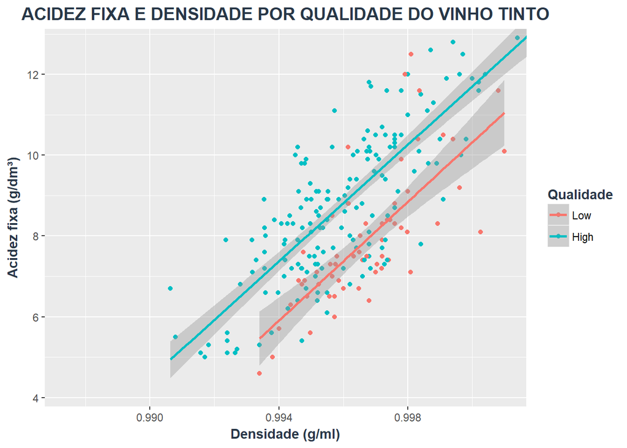

#### 8.6 Descrição do terceiro gráfico

Para os vinhos tintos, a propriedade química que melhor se relaciona com a densidade é a acidez fixa. Neste gráfico de dispersão foram removidos os pontos de vinhos de qualidade média para facilitar visualização da diferença entre os vinhos de alta e baixa qualidade. Nele, podemos observar que os tintos de alta qualidade tendem a ter menos densidade por acidez fixa. Esta densidade pode ser explicada pela acidez fixa em 63% dos casos (R^2 = 0,6308) nos tintos de alta qualidade e em 54% dos casos (R^2 = 0,5369) nos tintos de baixa qualidade.

#### 8.7 Quarto gráfico

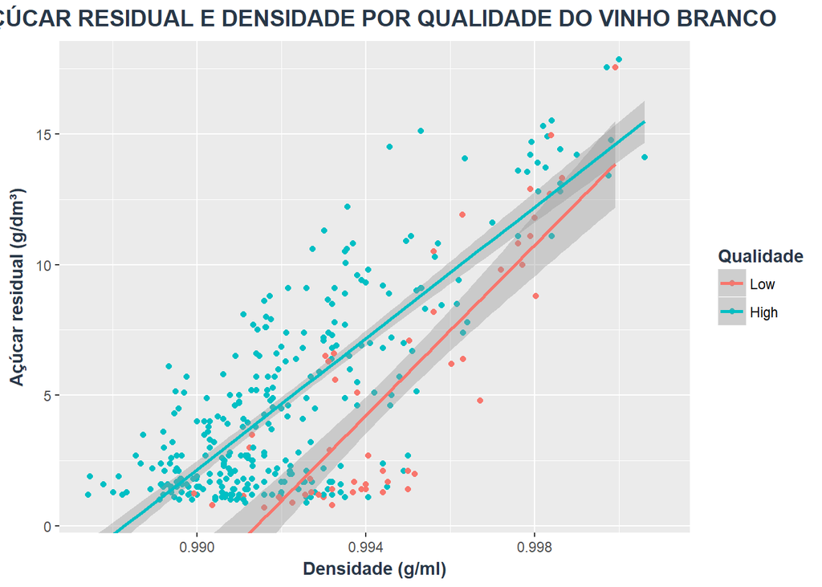

#### 8.8 Descrição do quarto gráfico

Para os vinhos brancos, a propriedade química que melhor se relaciona com a densidade é o açúcar residual. Neste gráfico de dispersão, mais uma vez, foram removidos os pontos de vinhos de qualidade média para facilitar visualização da diferença entre os vinhos de alta e baixa qualidade. Nele, podemos observar que os brancos de alta qualidade tendem a ter menos densidade por açúcar residual. Esta densidade pode ser explicada pelo açúcar residual em 68% dos casos (R^2 = 0,6844) nos brancos de alta qualidade e em 71% dos casos (R^2 = 0,7064) nos brancos de baixa qualidade.

### 9. REFLEXÃO

O conjunto de dados de “Vinho Verde” Português foi elaborado por uma amostra menor de cada tipo de vinho, tintos e brancos. Iniciei o projeto analisando a distribuição das variáveis independentes uma a uma com os gráficos univariados e, aos poucos, observando as diferenças entre os vinhos tintos e brancos.

Ao iniciar a análise dos gráficos bivariados, esperava encontrar pelo menos uma variável com relação forte com a qualidade. Ao invés, encontrei uma série de correlações moderadas ou fracas. O percentual alcóolico do vinho foi a propriedade química com maior correlação com a qualidade e, partindo dele, encontrei na densidade a melhor correlação com esta última. Seguindo esta lógica, explorei as diferenças entre os tipos de vinho, encontrando na acidez fixa a melhor correlação para os vinhos tintos e o açúcar residual a melhor correlação para os vinhos brancos.

Neste ponto, já estava claro que a qualidade dos vinhos é definido por uma relação complexa entre as diversas propriedades químicas. Mesmo simplificando a classificação da qualidade do vinho, não ficou claro o que diferencia um vinho de qualidade baixa de um de qualidade média. Os poucos vinhos classificados com baixa qualidade podem ser uma limitação deste conjunto de dados.

Ao final, foi possível encontrar sutis diferenças nos vinhos de alta qualidade ao analisar a densidade e acidez fixa para os vinhos tintos e açúcar residual e densidade para os vinhos brancos. Para futuros trabalhos, podem ser utilizadas técnicas estatísticas para seleção e combinação das propriedades químicas para procurar um modelo preditivo de qualidade, visto que os componentes da qualidade do vinho parecem se basear em um equilíbrio de diversos atributos.

### 10. REFERÊNCIAS

https://en.wikipedia.org/wiki/Acids_in_wine#In_wine_tasting

https://pt.wikipedia.org/wiki/PH

https://en.wikipedia.org/wiki/Feature_selection

https://pt.wikipedia.org/wiki/Estatística_descritiva

https://en.wikipedia.org/wiki/Effect_size

https://en.wikipedia.org/wiki/Correlation_and_dependence

http://rmarkdown.rstudio.com/index.html

https://cran.r-project.org/web/packages/corrplot/vignettes/corrplot-intro.html

https://s3.amazonaws.com/udacity-hosted-downloads/ud651/wineQualityInfo.txt

https://onlinecourses.science.psu.edu/stat857/node/224

https://stackoverflow.com/questions/14395569/how-to-output-text-in-the-r-console-without-creating-new-lines

https://stackoverflow.com/questions/23519224/extract-r-square-value-with-r-in-linear-models

https://stackoverflow.com/questions/12410908/combine-legends-for-color-and-shape-into-a-single-legend

https://stackoverflow.com/questions/37660694/add-legend-to-geom-vline

https://stackoverflow.com/questions/21982987/mean-per-group-in-a-data-frame

https://stackoverflow.com/questions/19876505/boxplot-show-the-value-of-mean

https://pt.stackoverflow.com/questions/6112/como-remover-uma-coluna-do-data-frame-em-r/6128#6128

http://ggplot2.tidyverse.org/reference/scale_brewer.html

http://ggplot2.tidyverse.org/reference/labs.html

http://ggplot2.tidyverse.org/reference/geom_density.html

http://ggplot2.tidyverse.org/reference/geom_bar.html

http://www.sthda.com/english/wiki/ggplot2-density-plot-quick-start-guide-r-software-and-data-visualization

http://www.sthda.com/english/wiki/ggplot2-title-main-axis-and-legend-titles